# Does colour influence the ratings of attractiveness?

*N* removed NAs: 2

*N* removed typo: 1

*N* removed <18: 25

*N* total clean: 122

| Group | *N* | *M*<sub>age</sub> | *M*<sub>rating</sub> |
| --- | --- | --- | --- |
| Control | 63 | 20.7 | 6.84 |
| Experim | 59 | 21.1 | 5.97 |

**Main analysis results**

*t*(120) = 6.15, *p* < .001

[interactive chart not shown]

[figure not shown]

[interactive chart not shown]

# Does colour influence the ratings of attractiveness?

Analysing Data, Candidate 218117

# Methods

## Participants

The final number of participants whose data was included in my results were 122 participants (*M*<sub>age</sub> = 20.89, range = 18 - 27). The mean, standard deviation and range of participants ages are shown in the table below:

Table *1 Participants Descriptives*

| *M*<sub>age</sub> | *SD*<sub>Age</sub> | Min<sub>Age</sub> | Max<sub>Age</sub> |
| --- | --- | --- | --- |
| 20.9 | 2.13 | 18 | 27 |

The number of participants who initially took part in the experiment was 150 participants. So, this table excludes 28 participants that were taken out. One participant was removed due to incorrect input of age, so their information was disregarded straight away. Twenty-five participants below the age 18 were also excluded as they were too young to be able to include their data. And finally, two participants whose age was inputted as N/A, their data was removed too as we cannot be sure they are over the age of 18.

## Design

Our conceptual hypothesis looks at whether colour influences attractiveness. We are investigating, if men were in conjunction with the colour red, would they be perceived as being more attractive. This was operationalised by participants shown a picture of one of the two pictures in a frame. In the control condition the frame was white and in the experimental condition the frame was red.

The participants were then asked how attractive they thought the male was in the picture, on a rating scale of 1-9 based on three questions. The first question was ‘how attractive do you think the person is?’, the second question is ‘how pleasant is this person to look at’ and the final question was ‘if i were to meet the person in this picture face to face, would i think he is attractive?’. Then an average rating, for each person, based on these three questions were produced in order to create a composite score.

The first variable we have is colour and this is measured on an independent categorical variable, as you either complete the control condition (white) or the experimental condition (red), not both. Therefore, colour would be our predictor in this case, as this is what we are manipulating. The outcome that would be produced is attractiveness, which is a continuous variable. This would be the continuous variable as, due to us comparing means, it is vital that we have a continuous varibale. These rating scales are on a scale of 1-9, where 9 is the most attractive and 1 being least attractive. This scale is also used within the composite scores, the average of all three questions attractiveness ratings. Meaning attractiveness is the outcome, as this is what changes due to our predictor.

The operational hypothesis of this study would be ‘does the colour of a frame around an image of a male impact the ratings of attractiveness he would receive?’. The statistical analysis i will us to test this will be a t-test, as we will be comparing two mean ratings between two separate conditions.

# Results

The general pattern of results shows that the mean composite score for the control condition was larger than the mean composite score for the experimental condition. These results are shown in the table below.

Table 2 *Summary of the data*

| Group | *N* | *M*<sub>Question1</sub> | *M*<sub>Question2</sub> | *M*<sub>Question3</sub> | *M*<sub>CompositeScore</sub> |
| --- | --- | --- | --- | --- | --- |
| control | 63 | 6.71 | 6.98 | 6.81 | 6.84 |
| experimental | 59 | 6.03 | 6.22 | 5.64 | 5.97 |

The t-test indicates that there was a significant difference in the mean attractiveness ratings of the red vs white colour group (*M*<sub>diff</sub> = 0.87, 95% CI [0.59, 1.15], *t* (120) = 6.15, *p* < .001)

This means that the control group was significantly greater (*M*<sub>attract</sub> = 6.84) in their attractiveness ratings than the experimental group (*M*<sub>attract</sub> = 5.97). Meaning that a white background had more of an impact on attractiveness ratings, compared to the red background. This goes against our hypothesis, as it was hypothesised that red would achieve higher ratings of attractiveness, not white.

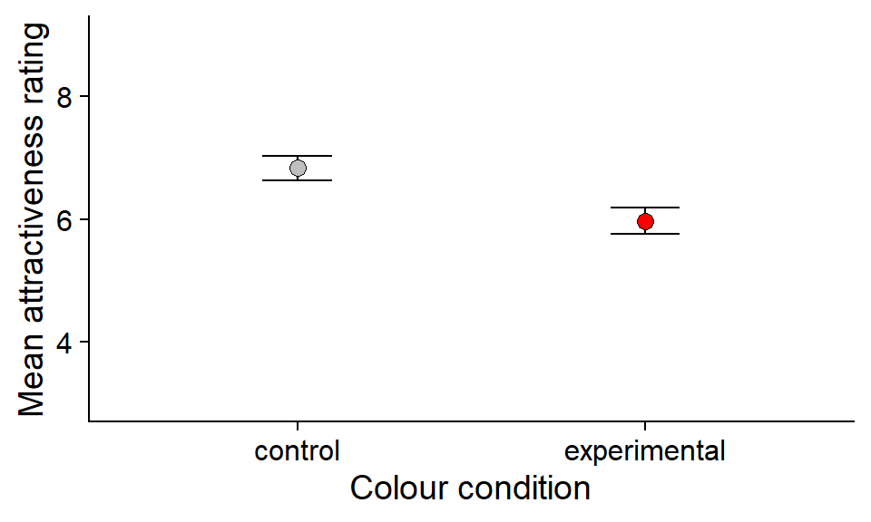

# Discussion

The main hypothesis of this experiment was people would receive a higher attractiveness rating when seen on the red background, compared to when see on the white background. Overall the results from my experiment indicate that the white background actually received higher attractiveness ratings than the red background. This shows that our results were the complete opposite to what we had hypothesised. Therefore, we had proved our original hypothesis to be incorrect.

My results also contradicted the results of the original study, as they found that the red background appears to influence women’s romantic attraction to men, not the white background (Elliot et al., 2010). Therefore, shows that the pattern of results in the original study, were the complete opposite to the results in my replication study. This means that research in this area may be incomplete as results differ from study to study. One reason, which may explain these differences in results, may be due to individual differences in women’s opinions. For example, one woman may find men more attractive in conjunction with the colour red, but others may not. Therefore, we cannot conclude that either red or white causes a women to perceive a man as being more attractive, as the findings in this area of research do not concede.

Although, another study looked at male participants rating women in red, white and black clothing on how attractive they perceived her, using a large sample size. Their results showed no difference in the rating of the attractiveness of women in the red or white condition (Peperkoorn et al., 2016). This study doesn’t support or go against my study’s results, it just suggests that they found no impact on attractiveness ratings when the colour changed. However, the experiments focused on testing males to measure attractiveness ratings towards females. This means that colour in conjunction with females may not influence attractiveness ratings, like colour in conjunction with males does. Therefore, shows that these findings may be gender specific. This could be a key area of focus for future research; to investigate if colour influences attractiveness ratings, can it be applied to both genders or if it is only specific to one gender. This would be done by carrying out the same study on both males and female participants to see if results are significant for both of these genders, or just one.

Other studies have shown that women, back in the 1900s, use to view men when in combination with the colour red as being of higher status and shown to be richer (Foundation, 2010). These findings were only associated with the colour red. This means that these findings also go against the results from my study as this specifies that, only the colour red, increases women’s perceptions of males being more well off than other males. Therefore, it suggests that the idea that red increases attractiveness is not only relevant to the current modern day, but also was an important concept over 100 years ago too. Suggesting that results have remained constant over many years and also different generations. Therefore, questioning the reliability of my results as no research has concluded that white has had more of an affect, on attractiveness ratings, than red does.

A final study showed that these experiments were not exclusive to humans but were also carried out on animals too. Research had been carried out on rhesus monkeys, where male and female monkeys were presented with the opposite sex on either a red or blue background. The results from this research was that, female monkeys’ looker longer at a picture of a male scrotum, on a red background, while males showed no bias (Hughes et al., 2015). This links back to Peperkoorn et al’s findings, as it suggests that the red effect may be gender specific, even in non-humans as well. But these findings do not support or go against my results, as the study used a red and blue background, instead of a white. This means that this could be a key area of research for future studies, as it would enable researchers to see whether results can be generalised to animals as well.

One particular issue within our study was the unusually small sample size of our participants. In my study we only had 122 participants, which was out of our control. From previous research it has been shown that having a larger sample size could dramatically impact the results. For example, Peperkoorn et al repeated their experiments, which found evidence of the red effect, and used a larger sample size. They found that by using a larger sample size meant that the results no longer supported the red effect (Peperkoorn et al., 2016). This implies how having a larger sample size could directly impact my results, as original findings of a white background increasing attractiveness ratings, may not still be the case if a larger sample size was used. In the future, studies should use much larger sample sizes in order to avoid drawing wrong conclusions from such a small sample size.

In summary, the main findings from my experiment were that white increases attractiveness ratings compared to red. Most other research carried out by other researchers in this area found that red increased attractiveness ratings, in comparison to white. This goes against my findings, but this could imply my research has been the first to find these results as of the year 2020 and could be a key reference for future research in this area.

# References

Elliot, A. J., Kayser, D. N., Greitemeyer, T., Lichtenfeld, S., Gramzow, R. H., Maier, M. A., & Liu, H. (2010). Red, rank, and romance in women viewing men. Journal of Experimental Psychology: General, 139(3), 399–417.

Foundation, A. V. H. (2010). Women Attracted to Men in Red, Research Shows.Retrieved 13 November 2019, from https://www.rochester.edu/news/show.php?id=3663.

Hughes, K. D., Higham, J. P., Allen, W. L., Elliot, A. J., & Hayden, B. Y. (2015). Extraneous colour affects female macaques’ gaze preference for photographs of male conspecifics.Evolution and Human Behaviour: Official Journal of the Human Behaviour and Evolution Society, 36(1), 25–31. https://doi.org/10.1016/j.evolhumbehav.2014.08.003

Peperkoorn, L. S., Roberts, S. C., & Pollet, T. V. (2016). Revisiting the red effect on attractiveness and sexual receptivity: No effect of the color red on human mate preferences. Evolutionary Psychology, 14(4), 1474704916673841.